# Econometrics 2B: Time Series Analysis - Homework

Tim Kühleis, Bartolomeo Perazzoli

2025-05-25

# Exercise 1 - Univariate Analysis

## Exercise 1.1: Plot each time-series in levels before applying any transformations

```r
knitr::include_graphics("exercise_1_combined_plot.pdf")
```

[figure not shown]

### Comment on these time series Plots

**Credit Spread Plot**

Before turning to the first plot, we briefly introduce the nature and construction of this time series, as it is less conventional than the other two, which most Economists should be familiar with. The ICE BofA Euro High Yield Index Option-Adjusted Spread (OAS) measures the additional yield that investors require, over the euro area risk-free rate, to hold euro-denominated corporate bonds rated below investment grade (i.e., lower than BB by Fitch or Ba1 by Moody’s). Only publicly issued bonds with an outstanding volume above €100 million from issuers domiciled in countries with investment-grade sovereign ratings are included. The spread is adjusted for embedded options and aggregated using market-capitalization weighting. In “less technical” terms, the series captures the risk premium compared to the spot Treasury curve associated with holding Eurozone “junk” bonds, reflecting both credit and liquidity risk.

The plot shows that the credit spread generally fluctuates within a 3–5 percentage point band during stable periods. Sharp spikes in the spread coincide with major episodes of financial turmoil. The elevated spread in 2001–2003, peaking around 15%, reflects heightened risk perceptions during the burst of the “dot-com-bubble” and the post-9/11 recession. The most pronounced increase occurs during the global financial crisis (2007–2009), with a peak above 20% following the collapse of the US-Bank Lehman Brothers in September 2008. The final surge in our time series between 2011 and 2013 reflects the European sovereign debt crisis.

However, it is important to note that the index only includes high-yield corporate bonds issued by firms domiciled in countries with investment-grade sovereign ratings, such as Germany. As a result, it does not fully capture the sharp rise in credit spreads for corporations based in fiscally less stable countries like Greece and Portugal, both of which lost investment-grade status in 2010. The observed increase in spreads during the European debt crisis thus primarily reflects broader market risk aversion and heightened perceptions of credit risk among issuers in core Eurozone economies—particularly those expected to act as lenders of last resort. For our analysis this is exactly what we want to focus on.

For our time series analysis, visually inspecting the series we see the series exhibits strong mean-reversion around a constant level and no visible trend, suggesting weak stationarity.

**Industrial Production Index**

The second plot shows Germany’s industrial production index (excluding construction) from 2000 to 2019, expressed in real terms with 2015 as the base year. We can divide the evolution of the series into several key phases. From 2003 to mid-2008, the index displays a steady and almost linear upward trend, reflecting sustained industrial growth. This is followed by a sharp contraction of over 20% during the global financial crisis. The recovery begins in early 2009 but remains gradual and volatile. Pre-crisis output levels are only reached again by late 2015, an astounding 7 years after the GFC began. After 2017, the series begins to decline again, with little evidence of structural growth, indicating a potential stagnation of the German industrial sector in the face of increasing global uncertainty.

This time series effectively captures the cyclical and structural dynamics of Germany’s export-oriented manufacturing economy. The dramatic collapse in 2008–2009 underscores Germany’s exposure to global trade disruptions during the financial crisis. The sluggish recovery and cyclical fluctuations reflect subsequent headwinds, including the euro area sovereign debt crisis (2011–2012) and the China-led global slowdown in 2015—particularly relevant given China’s role as a major importer of German industrial goods. The post-2017 downturn likely stems from declining external demand and rising global trade tensions.

Visual inspection suggests that the series is clearly non-stationary, characterized by both a deterministic trend and a shift in level post GFC. To obtain a stationary series, we take the first difference of the outcome. Additionally, we will use a logarithmic transformation as log-differences can be interpreted as month-over-month growth rates in industrial production.

**Consumer Price Index**

The third plot show the harmonized consumer price index (HICP) for Germany from 2000 to 2019, with 2015 as the base year. Over the entire sample period, the series exhibits a smooth and almost linear upward trend, increasing from approximately 80 to 105. Assuming linearity, this corresponds to an average annual growth rate of roughly 1.25 percentage points, which is consistent with the broader macroeconomic environment of low and stable inflation during this time period. Notably, the sample ends just before two major inflationary shocks: the COVID-19 pandemic and the 2022 energy crisis triggered by Russia’s invasion of Ukraine—both of which led to significant price pressures in subsequent years.

Throughout the period shown, the index displays no signs of mean reversion, and inflation appears largely unaffected by the external shocks visible in the other two series. Based on visual inspection, the series clearly exhibits a deterministic trend component. Thus, it may still be trend-stationary. To determine whether the process is stationary or not, we will conduct formal unit root tests in the next exercise, which will provide more robust evidence regarding the stationarity properties of the series. If we conclude, at least as a first step, that the series is non-stationary, we will apply log differencing, consistent with our approach to the IPI series. This transformation may yield a stationary process and additionally offers a smooth interpretation as month-over-month inflation rates.

## Exercise 1.2: Conduct unit root and stationarity tests for each series

Given our previous results, we now propose to conduct unit root and stationarity tests in the following order:

1. We log-transform CPI and IPI for two reasons. First, the underlying trends in these series appear to be multiplicative rather than linear. Taking logs allows us to linearize the relationship, which is necessary to apply linear time series models such as AR or ARMA. Second, since we will later difference the series to achieve stationarity (based on our earlier visual inspection suggesting I(1) behavior), the log-differenced series can be conveniently interpreted as month-over-month growth rates.
2. We proceed by conducting standard unit root and stationarity tests in the following order: – First, we apply the ADF, ERS/DF_GLS, Phillips-Perron, and KPSS tests to the original (non-differenced) series to check for stationarity of the original series – If these tests suggest non-stationarity, we continue by applying same tests (altough with possibly different trend specifications) to the first-differenced series. If those are found to be stationary, this confirms that the series are integrated of order one, I(1)

### Level Series without integration:

```r
cat(table1_latex)
```

**Log Industrial Production** We obtained mixed results regarding the stationarity of the log industrial production series. Both the ADF and PP tests failed to reject a unit root at standard confidence levels, indicatin non-stationarity. However, the KPSS test indicated stationarity at the 1% and 5% levels, though it was borderline at 10%. Given this conflicting evidence and the general tendency to conclude non-stationarity in such cases, we lean towards the safer option and conclude that the series is non-stationary, requiring first-order integration.

**Log CPI** Both the ADF (–1.537) and PP (–1.564) test statistics are far above the critical values, confirming failure to reject the unit root. The KPSS test statistic (0.83) strongly exceeds all critical values, clearly rejecting trend stationarity. Together, the tests provide robust evidence that CPI (log) is non-stationary in levels, which aligns with expectations for price indices.

**Credit Spread** The ADF test statistic (–2.606) does not exceed the 5% critical value (–2.88), so we fail to reject the unit root. The KPSS test (0.807 > all critical values) also rejects stationarity. However, the PP test shows an extremely large negative statistic (–13.002) with a near-zero p-value, strongly rejecting the null of a unit root. This conflicting evidence suggests caution, but overall, ADF and KPSS both support non-stationarity.

### I(1) Series:

First before we do the unit root tests we again plot the time series of the integrated processes for inspection and conclude the following about the appropriate setup for unit root tests:

- **Industrial Production (Δlog IPI):** The series fluctuates around a non-zero constant mean without a trend, justifying the use of drift specifications for ADF/PP and a level null in KPSS.
- **CPI (Δlog CPI):** The differenced price index series also shows no trend, only short-term fluctuations around a stable mean. This supports the same test setup.
- **Credit Spread (Δ):** Although more volatile, especially around 2009, the series remains mean-reverting without trend, making the constant-only specification reasonable.

```r
cat(table2_latex)
```

After doing the tests, we conclude the following: - $\Delta$ **log Industrial Production:** All three tests now clearly point toward stationarity. ADF and PP strongly reject the unit root, while the KPSS test fails to reject level stationarity. This confirms that first differencing was sufficient to achieve stationarity for the industrial production series.

- $\Delta$ **log CPI:** The test results are consistent and conclusive. Both the ADF and PP tests strongly reject the null of a unit root, and the KPSS test does not reject level stationarity. We therefore conclude that the first-differenced log CPI series is stationary.
- $\Delta$ **Credit Spread:** As with the other two series, all tests align. ADF and PP reject the presence of a unit root by a wide margin, and KPSS indicates no violation of level stationarity. This supports the conclusion that the differenced credit spread series is stationary.

## Exercise 1.3: Identify and estimate candidate AR(p) and ARMA(p,q) models using the ACF and PACF. Which model would you choose according to information criteria? Comment the results

### Industrial Production Index:

```r
knitr::include_graphics("ipi_acf_grid.pdf")
```

[figure not shown]

```r
model_tables$industrial_bic
```

```r
model_tables$industrial_aic
```

**Comment:** Inspecting the PACF plot, the pattern appears somewhat irregular. We observe a significant spike at lag 1, a non-significant lag 2, followed by another significant spike at lag 3. This suggests an autoregressive process of order between 1 and 3. As a conservative choice, we initially lean toward an AR(3) specification. This is further supported by the ranking of optimal candidates by the Bayesian Information Criterion (BIC), where the AR(3) model appears as the fourth-best candidate, performing only marginally worse than the top models.

Based on the information criteria, the BIC selects an MA(3) process as the optimal model, while the AIC favors a much more complex ARMA(5,7) specification. *(Reminder: since we are modeling the I(1) series, this corresponds to an ARIMA(5,1,7) on the original series.)* Once again, this illustrates AIC’s tendency to prefer more heavily parameterized models that were not clearly supported by the ACF or PACF plots. We therefore select the MA(3) model as our preferred specification—it performs nearly as well under AIC and is more parsimonious. The MA(3) Model was also chosen by the Hyndman-Khandakar-Algorithm when optimizing with respect to the BIC.

Residual diagnostics (see final table in Exercise 1.3) confirm that the MA(3) model is well-specified. The Ljung–Box test fails to reject the null hypothesis of no autocorrelation. While the Jarque–Bera test rejects normality, this is common in empirical macroeconomic applications and not a major concern, especially since we are interested in forecasting and not inference.

### Consumer Price Index:

```r
knitr::include_graphics("cpi_acf_grid.pdf")
```

[figure not shown]

```r
model_tables$core_infl_bic
```

```r
model_tables$core_infl_aic
```

**Comment:** Looking at the MoM inflation rate (log-differenced CPI), the ACF and PACF plots show no significant autocorrelation at any lag, as all values remain well within the confidence bands. Based on visual inspection alone, this pattern is most consistent with a simple white noise process.

This impression is confirmed by the BIC, which selects an ARMA(0,0) model, i.e. pure white noise. The AIC, on the other hand, again favors a more complex model *(in this case, an ARMA(2,2) process)*. However, even under AIC, the improvement in fit relative to ARMA(0,0) is marginal and does not justify the added complexity, especially given the lack of support from the correlogram.

Turning to residual diagnostics, we fail to reject both null hypotheses of the Ljung–Box test (no autocorrelation) and the Jarque–Bera test (normality) for the white noise model. These results provide further evidence for our initial conclusion that the CPI time series—after differencing—can reasonably be modeled as a white noise process.

### Credit Spread Index:

```r
knitr::include_graphics("cs_acf_grid.pdf")
```

[figure not shown]

```r
model_tables$credit_spread_bic
```

```r
model_tables$credit_spread_aic
```

**Comment:** Inspecting the ACF and PACF plots for the credit spread change (i.e. first difference) series again reveals a somewhat non-standard pattern. The ACF shows a large significant spike at lag 1, followed by additional significant values at lags 2 and 4, as well as a highly negative spike at lag 6. The PACF similarly exhibits a strong positive spike at lag 1 and a large negative spike at lag 6. While not a textbook case, this pattern is most plausibly associated with an AR(1) or possibly an AR(6) process.

Turning to the information criteria, the BIC selects an ARMA(1,0) process, i.e. an AR(1), as the preferred specification. The next-best BIC candidate is an MA(1), but the visual evidence does not support a pure MA process. The AIC, as before, chooses a more complex model—namely, an ARMA(1,6)—which comes with a considerable reduction in AIC relative to the AR(1) model. Nevertheless, for reasons of parsimony and interpretability, we adopt **AR(1)** as our baseline model.

Finally, examining the residual diagnostics, we find that the AR(1) model passes the Ljung–Box test (i.e., we fail to reject the null of no autocorrelation), while the Jarque–Bera test again rejects normality, typical for Macroeconometrics. Based on these results, we conclude that the AR(1) specification sufficiently captures the serial dependence in the credit spread series.

### Residual Diagnostics:

```r
#–– Optional: map internal names to pretty labels ––
pretty_names <- c(
  industrial = "Industrial Production Index",
  core_infl = "Core Inflation",
  credit_spread = "Credit Spread"
)

#–– 1) Extract top 1 by BIC and top 1 by AIC for each series ––
diag_list <- lapply(names(all_models), function(series) {
  # grab the top candidates
  bic_row <- all_models[[series]]$topBIC[1, ]
  aic_row <- all_models[[series]]$topAIC[1, ]
  rows   <- rbind(bic_row, aic_row)

  # loop over BIC/AIC rows
  do.call(rbind, lapply(seq_len(nrow(rows)), function(i) {
    p <- rows$p[i]
    q <- rows$q[i]
    # fit the model
    fit <- Arima(
      ts_list[[series]],
      order            = c(p, 0, q),
      include.constant = TRUE,
      method           = "ML"
    )
    res <- residuals(fit)
    # diagnostics
    lb <- Box.test(res, lag = 20, type = "Ljung-Box")
    jb <- jarque.bera.test(res)
    data.frame(
      Series    = pretty_names[series],
      Criterion = c("BIC", "AIC")[i],
      Model     = sprintf("ARMA(%d,%d)", p, q),
      `LB Stat` = round(lb$statistic, 2),
      `LB p-val`= sprintf("%.3f", lb$p.value),
      `JB Stat` = round(jb$statistic, 2),
      `JB p-val`= sprintf("%.3f", jb$p.value),
      check.names = FALSE,
      stringsAsFactors = FALSE
    )
  }))
})

#–– 2) Combine and print LaTeX table ––
diag_tbl <- do.call(rbind, diag_list)
print(
  xtable(
    diag_tbl,
    caption = "Residual diagnostics for top ARMA models by BIC and AIC",
    label   = "tab:resid_top_bic_aic"
  ),
  include.rownames      = FALSE,
  booktabs              = TRUE,
  caption.placement     = "top",
  sanitize.text.function = identity
)
```

% latex table generated in R 4.4.3 by xtable 1.8-4 package % Sun May 25 20:33:49 2025

## Comment on the Plots:

**Conclusion**  
The AR(3) model provides a reasonable short-term baseline, capturing autocorrelation but smoothing over extreme movements. For more accurate or structural insights, models with additional indicators (e.g., VAR) would be more appropriate. To better understand crisis episodes, nonlinear time series methods should be considered, as linear models struggle to capture such dynamics.

# Exercise 2 - : Multivariate analysis

## Exercise 2.1: Select the optimal lag length for your multivariate model

AIC(n) HQ(n) SC(n) FPE(n) 6 3 1 6

## Exercise 2.2: Estimate the model and verify that the residuals satisfy standard properties

**Comment:**

We estimated the VAR(6) model in the standard way in the preceding code chunk. As is common in applied macroeconomic work, we do not report the estimated coefficients here, since our focus lies not on reduced-form parameters but on the dynamic relationships captured by **Impulse Response Functions (IRFs)**, which we will analyze in a later section. (Granger causality could be of interest in some cases, but is not required here and is thus omitted.)

### Redisual diagnostics:

- **Portmanteau Test for Serial Correlation**  
  With a p-value of 0.193, we do *not reject* the null of no residual autocorrelation at standard confidence levels. This supports the chosen lag length and confirms that the model captures the joint dynamics of the series sufficiently well. This is a necessary condition for valid inference using IRFs and forecasts.
- **ARCH Test for Conditional Heteroskedasticity**  
  The null of no ARCH effects is *strongly rejected* (p ≈ 0), indicating time-varying volatility in the residuals. While this does not bias coefficient estimates, it does invalidate inference based on homoskedastic standard errors. This is why we will rely on *bootstrapped IRFs* in the next step.
- **Jarque–Bera Test for Normality**  
  We also *strongly reject* the null of normally distributed residuals. This likely reflects skewness or heavy tails. While non-normality limits the applicability of asymptotic theory, most procedures we apply (e.g. bootstrapping) are robust to such deviations.

## Exercise 2.3: Plot the in-sample and out-of-sample forecasts for one of the series

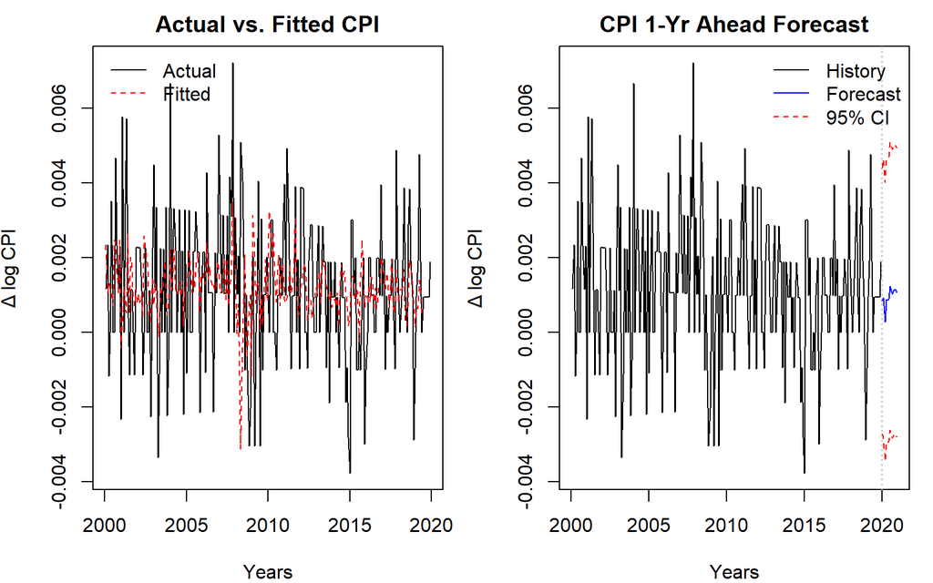

```r
# 1) In-sample fit vs actual
ts_hist   <- ts(data_mat[,"cpi"],
                start     = start(data_mat),
                frequency = frequency(data_mat))
ts_fitted <- ts(fitted(var_mod)[,"cpi"],
                start     = start(data_mat),
                frequency = frequency(data_mat))

# 2) Out-of-sample forecast
fcast   <- predict(var_mod, n.ahead = 12, ci = 0.95)
cpi_mat <- fcast$fcst[["cpi"]]
ts_fc    <- ts(cpi_mat[,"fcst"],
               start     = end(data_mat) + c(0,1),
               frequency = frequency(data_mat))
ts_lo    <- ts(cpi_mat[,"lower"],
               start     = start(ts_fc),
               frequency = frequency(data_mat))
ts_hi    <- ts(cpi_mat[,"upper"],
               start     = start(ts_fc),
               frequency = frequency(data_mat))


par(mfrow = c(1,2), mar = c(4,4,2,1))

# Panel 1
plot(ts_hist,
     ylab = expression(Δ~log~CPI),
     xlab = "Years",
     main = "Actual vs. Fitted CPI",
     col  = "black", lty = 1)
lines(ts_fitted, col = "red", lty = 2)
legend("topleft",
       legend = c("Actual","Fitted"),
       col    = c("black","red"),
       lty    = c(1,2),
       bty    = "n")

# Panel 2
plot(ts_hist,
     xlim = c(time(ts_hist)[1], time(ts_hi)[length(ts_hi)]),
     ylim = range(c(ts_hist, ts_lo, ts_hi)),
     ylab = expression(Δ~log~CPI),
     xlab = "Years",
     main = "CPI 1-Yr Ahead Forecast",
     col  = "black", lty = 1)
abline(v = time(ts_fc)[1], lty = 3, col = "grey")
lines(ts_fc, col = "blue", lty = 1)
lines(ts_lo, col = "red",  lty = 2)
lines(ts_hi, col = "red",  lty = 2)
legend("topright",
       legend = c("History","Forecast","95% CI"),
       col    = c("black","blue","red"),
       lty    = c(1,1,2),
       bty    = "n")
```

```r
par(mfrow = c(1,1))
```

### Panel 1: Actual vs. Fitted CPI

We estimate a VAR(6) model to capture the joint dynamics of the system. The solid black line shows the observed month-over-month inflation rate in Germany ($\Delta$ log CPI), while the red dashed line represents the fitted values produced by the VAR(6) model over the estimation window. This plot illustrates the in-sample fit—that is, how well the model explains the data it was trained on.

Overall, the model captures the general trend and propagation of inflation reasonably well. However, the fitted series is noticeably smoother than the actual data, highlighting the model’s inability to match the observed volatility. This limitation is particularly visible during periods of economic disruption, for instance, the 2008–2009 Global Financial Crisis and the 2015 deflationary episode (likely driven by the collapse in global oil prices). These episodes are better understood as nonlinear shocks or “black-swan” events, which simple linear models like VARs are not designed to capture.

Despite this, there is no evidence of persistent over- or underprediction bias. The residuals fluctuate around zero, suggesting the model effectively tracks low-frequency dynamics, even if it fails to capture high-frequency noise and sudden shocks.

### Panel 2: CPI 1-Year Ahead Forecast

The right panel shows the out-of-sample forecast. The black line again plots observed MoM inflation, while the blue line represents the 12-month-ahead forecast from the VAR(6) model. The red dashed lines indicate the 95% confidence interval.

As expected, the confidence band widens over the forecast horizon, reflecting the accumulating uncertainty the further we forecast into the future. The point forecast itself is conservative, hovering slightly above zero. This reflects the model’s expectation of stable inflation dynamics in the near term, given past information.

However, caution is warranted. These confidence intervals are analytic, and do not account for the non-Gaussian features of the residuals. As we discuss later, bootstrapped intervals (not shown here) are more robust in the presence of heteroskedasticity and fat tails, which are typical in macroeconomic data.

Importantly, the confidence bands are wide—allowing for outcomes ranging from high deflation (–0.3% MoM ~ 3.7%p.a.) to high inflation (0.5% MoM ~ 6.7% p.a.). Given this wide range, the point forecast offers limited practical guidance. The high degree of uncertainty simply reflects the noisy nature of monthly inflation, and points to the limitations of simple linear VAR models in predictive settings.

In conclusion, the VAR(6) model delivers an acceptable in-sample fit and a plausible forecast under the assumption of linearity and Gaussian errors. However, its shortcomings become evident when faced with real-world volatility and structural breaks. These results underscore the need for richer models, including nonlinear dynamics, time-varying parameters, or conditional heteroskedasticity, particularly when the objective is risk assessment or forecasting under crisis conditions.

## Exercise 2.4: Using the Cholesky decomposition, explain the reasoning behind your chosen ordering of variables

We apply the following Cholesky ordering to our three variables:

$$\Delta \text{Credit Spread} \longrightarrow \Delta \text{Industrial
Production} \longrightarrow \Delta \text{CPI}$$

This recursive ordering reflects the assumed speed at which each variable responds to exogenous shocks or new information. The structure is consistent with standard economic intuition.

We place **credit spreads** first, since financial markets, under the assumption of at least partial informational efficiency, are expected to react almost instantaneously to new information. As such, we treat changes in credit spreads as contemporaneously exogenous, allowing them to influence the other variables within the same month but not vice versa.

**Industrial production** is ordered second. Real economic activity typically responds to changes in financial conditions with a short delay (within the month), for example through adjustments in investment or inventory decisions. Moreover, industrial production data is often published with a lag, whereas credit spreads reflect real-time market information. This asymmetry in data availability further supports the chosen ordering.

Lastly, we place **consumer prices** at the end. Prices are generally sticky and slow to adjust due to nominal rigidities such as wage contracts, menu costs, or pricing norms. It is therefore plausible to assume that inflation does not contemporaneously affect either credit markets or real activity. However, inflation itself may respond within the same period to shocks in credit spreads and output.

Under this ordering, credit spread shocks are allowed to affect both industrial production and prices contemporaneously; shocks to industrial production can affect prices; but the reverse contemporaneous effects are ruled out. This structure imposes a recursive causal hierarchy that aligns well with both theory and the observed dynamics in the data.

## Exercise 2.5: Show the orthogonalized impulse response functions for your system

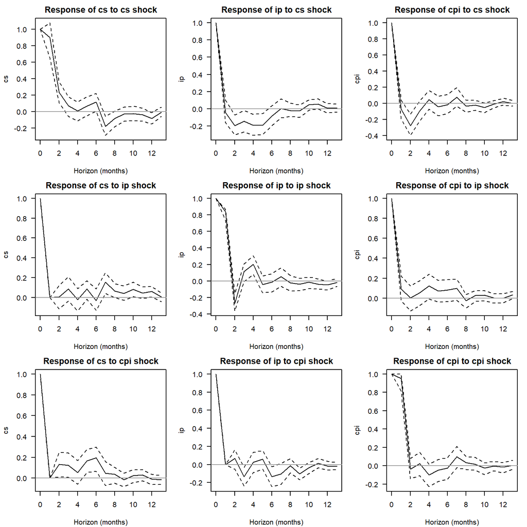

#### Response to a 1 SD increase in Credit Spread change

The credit spread (CS) jumps sharply on impact, as expected, and gradually decays back toward zero by month 3–4. This suggests short-lived persistence of shocks in the growth rate of credit spreads.

Inflation (CPI) growth also dips initially (trough ≈ –0.25 SD at month 2) but recovers more quickly—already by month 3, effects are minor and mostly indistinguishable from zero.

Overall, a one-standard-deviation tightening in financial conditions (wider credit spread) leads to a short-run contraction in both output and prices. Even though the effects on growth rates are transitory, all series are I(1), meaning that in levels, both IP and CPI are pushed onto a lower trajectory. This implies persistent real-side consequences from temporary financial stress.

#### Response to a 1 SD increase in MoM output growth (IP)

Credit spreads exhibit no notable response to an output growth shock—this is largely mechanical due to the Cholesky ordering, which assumes output does not contemporaneously affect spreads.

The response of inflation is modest and delayed, peaking at around +0.1 standard deviations in month 4 before gradually reverting to zero. However, given the width of the confidence bands, we cannot conclude that this effect is statistically distinguishable from zero.

#### Response to a 1 SD increase in MoM inflation (CPI)

Even the CPI growth rate itself shows no persistence: it initially overshoots and then quickly reverts. The lack of amplification implies that CPI shocks are largely absorbed without broader macro spillovers.

### General Comments

Across all responses, impulse effects are modest and short-lived—most return to zero within 6–8 months. Since the VAR was estimated in first differences, this implies the level variables experience small but permanent shifts.

Importantly, the Cholesky ordering (CS → IP → CPI) shapes the results. By placing CS first, we assume financial conditions affect the real and nominal sides contemporaneously, but not the other way around. This assumption helps identify financial shocks cleanly, but alternative orderings could change estimated effects especially for inflation dynamics.

Finally, while the magnitudes are not large (typically around 0.1–0.3 SD), they are meaningful given the monthly frequency. The real-side response to financial shocks is consistent with what we would expect from the literature, even if the estimated effects are not dramatic.

*NB: Since all series are non-stationary, we had to apply first differencing before estimating the VAR. While this ensures statistical validity, it also makes the results somewhat harder to interpret economically, as we are now modeling changes rather than levels. As a result, the dynamics may appear less intuitive or economically rich. In such settings, approaches based on Vector Error Correction Models (VECMs) could offer more informative insights by explicitly capturing long-run relationships between the variables.*

## Exercise 2.6: Modify the ordering of the variables and comment how this affects your results

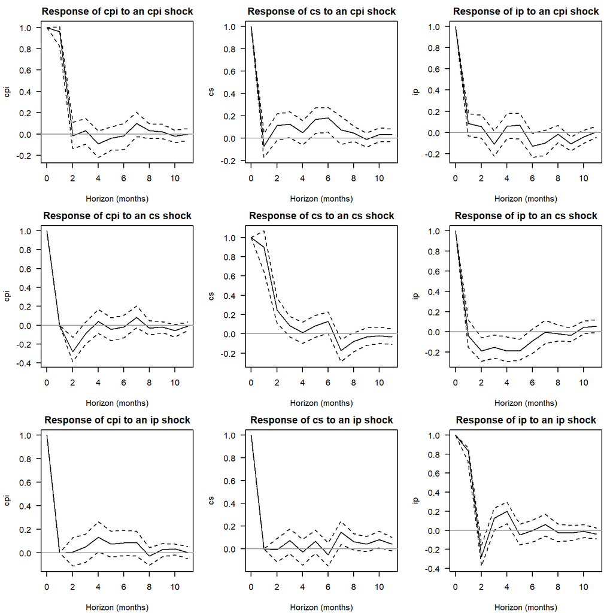

As an alternative Cholesky ordering, we test **CPI → Credit Spread → Industrial Production**. The idea is that inflation shocks arrive first, prompting an immediate reaction in financial markets. Real activity responds last, adjusting only after observing both the inflation surprise and its impact on credit conditions.

### Comment on the impact of a shock to the credit spread change:

**Interpretation:** Financial tightening has a clear and persistent effect dampening effect on output growth. Additionally, financial tightening seems somewhat persistent.

### Comment on the impact of an shock to the Industrial-production MoM growt rate

IP growth shows the standard transitory pattern—sharp increase on impact, then an undershoot and return to baseline by month 6. Given the Cholesky ordering, neither CPI nor credit spreads respond significantly.